# Self-Driving Car Engineer Nanodegree

## Project: Build a Traffic Sign Recognition Classifier

In this notebook, a template is provided for you to implement your functionality in stages, which is required to successfully complete this project. If additional code is required that cannot be included in the notebook, be sure that the Python code is successfully imported and included in your submission if necessary.

In addition to implementing code, there is a writeup to complete. The writeup should be completed in a separate file, which can be either a markdown file or a pdf document. There is a [write up template](https://github.com/udacity/CarND-Traffic-Sign-Classifier-Project/blob/master/writeup_template.md) that can be used to guide the writing process. Completing the code template and writeup template will cover all of the [rubric points](https://review.udacity.com/#!/rubrics/481/view) for this project.

The [rubric](https://review.udacity.com/#!/rubrics/481/view) contains "Stand Out Suggestions" for enhancing the project beyond the minimum requirements. The stand out suggestions are optional. If you decide to pursue the "stand out suggestions", you can include the code in this Ipython notebook and also discuss the results in the writeup file.

> **Note:** Code and Markdown cells can be executed using the **Shift + Enter** keyboard shortcut. In addition, Markdown cells can be edited by typically double-clicking the cell to enter edit mode.

## Step 0: Load The Data

```python
# Load pickled data
import pickle

training_file = "./traffic-signs-data/train.p"
validation_file= "./traffic-signs-data/valid.p"
testing_file = "./traffic-signs-data/test.p"

with open(training_file, mode='rb') as f:
    train = pickle.load(f)
with open(validation_file, mode='rb') as f:
    valid = pickle.load(f)
with open(testing_file, mode='rb') as f:
    test = pickle.load(f)

X_train, y_train = train['features'], train['labels']
X_valid, y_valid = valid['features'], valid['labels']
X_test, y_test = test['features'], test['labels']
```

```python
import matplotlib.pyplot as plt
import numpy as np
import cv2
%matplotlib inline
```

## Step 1: Dataset Summary & Exploration

The pickled data is a dictionary with 4 key/value pairs:

- `'features'` is a 4D array containing raw pixel data of the traffic sign images, (num examples, width, height, channels).
- `'labels'` is a 1D array containing the label/class id of the traffic sign. The file `signnames.csv` contains id -> name mappings for each id.
- `'sizes'` is a list containing tuples, (width, height) representing the original width and height the image.
- `'coords'` is a list containing tuples, (x1, y1, x2, y2) representing coordinates of a bounding box around the sign in the image. **THESE COORDINATES ASSUME THE ORIGINAL IMAGE. THE PICKLED DATA CONTAINS RESIZED VERSIONS (32 by 32) OF THESE IMAGES**

Complete the basic data summary below. Use python, numpy and/or pandas methods to calculate the data summary rather than hard coding the results. For example, the [pandas shape method](http://pandas.pydata.org/pandas-docs/stable/generated/pandas.DataFrame.shape.html) might be useful for calculating some of the summary results.

```python
from sklearn.utils import shuffle

X_train, y_train = shuffle(X_train, y_train)
X_valid, y_valid = shuffle(X_valid, y_valid)
```

### Provide a Basic Summary of the Data Set Using Python, Numpy and/or Pandas

```python
### Replace each question mark with the appropriate value.
### Use python, pandas or numpy methods rather than hard coding the results

n_train = X_train.shape[0]

n_test = X_test.shape[0]

n_classes = max(y_train)-min(y_train)+1

image_shape = (X_train.shape[1],X_train.shape[2],X_train.shape[3])

signnames = []
with open("signnames.csv",'r') as sign_file:
    for i,line in enumerate(sign_file):
        if i != 0:
            signnames.append(line.split(',')[-1])
            signnames[-1] = signnames[-1][:-1]
signnames[11] = "Right of Way"

print("Number of training examples =", n_train)
print("Number of validation examples =", X_valid.shape[0])
print("Number of testing examples =", n_test)
print("Image data shape =", image_shape)
print("Number of classes =", n_classes)
```

```
Number of training examples = 34799
Number of validation examples = 4410
Number of testing examples = 12630
Image data shape = (32, 32, 3)
Number of classes = 43
```

### Include an exploratory visualization of the dataset

Visualize the German Traffic Signs Dataset using the pickled file(s). This is open ended, suggestions include: plotting traffic sign images, plotting the count of each sign, etc.

The [Matplotlib](http://matplotlib.org/) [examples](http://matplotlib.org/examples/index.html) and [gallery](http://matplotlib.org/gallery.html) pages are a great resource for doing visualizations in Python.

**NOTE:** It's recommended you start with something simple first. If you wish to do more, come back to it after you've completed the rest of the sections.

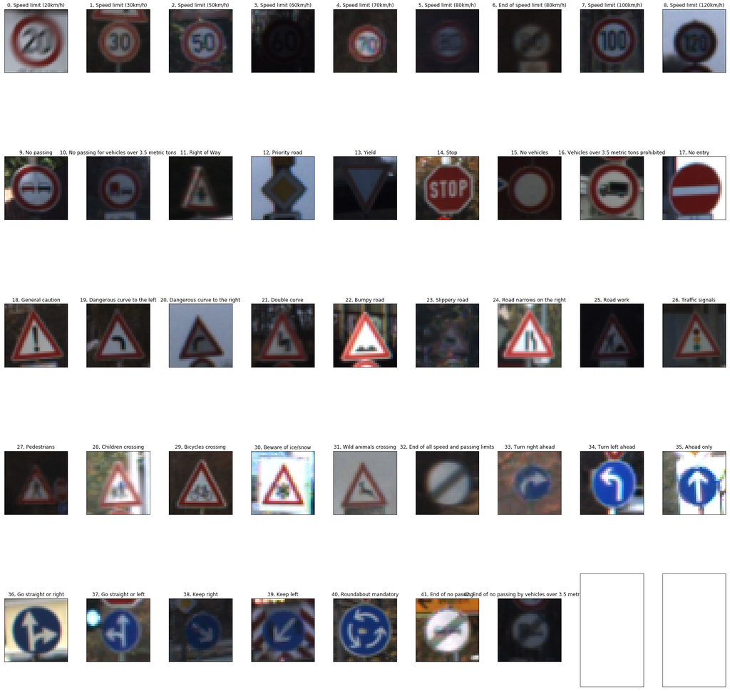

```python
### Data exploration visualization code goes here.
### Feel free to use as many code cells as needed.

fig_rows = 5
fig_cols = 9
fig, axes = plt.subplots(fig_rows, fig_cols, figsize=(32, 32),
                         subplot_kw={'xticks': [], 'yticks': []})

fig.subplots_adjust(hspace=0.3, wspace=0.3)

sign_types = [0]*n_classes
for i,sample in enumerate(y_train):
    sign_types[sample] = X_train[i]

for i,ax in enumerate(axes.flat):
    if i < len(sign_types):
        ax.imshow(sign_types[i])
        ax.set_title(str(i) + ", " + signnames[i])
plt.savefig('examples/sign_types.png')
plt.show()
```

## Step 2: Design and Test a Model Architecture

Design and implement a deep learning model that learns to recognize traffic signs. Train and test your model on the [German Traffic Sign Dataset](http://benchmark.ini.rub.de/?section=gtsrb&subsection=dataset).

The LeNet-5 implementation shown in the classroom at the end of the CNN lesson is a solid starting point. You'll have to change the number of classes and possibly the preprocessing, but aside from that it's plug and play!

With the LeNet-5 solution from the lecture, you should expect a validation set accuracy of about 0.89. To meet specifications, the validation set accuracy will need to be at least 0.93. It is possible to get an even higher accuracy, but 0.93 is the minimum for a successful project submission.

There are various aspects to consider when thinking about this problem:

- Neural network architecture (is the network over or underfitting?)
- Play around preprocessing techniques (normalization, rgb to grayscale, etc)
- Number of examples per label (some have more than others).
- Generate fake data.

Here is an example of a [published baseline model on this problem](http://yann.lecun.com/exdb/publis/pdf/sermanet-ijcnn-11.pdf). It's not required to be familiar with the approach used in the paper but, it's good practice to try to read papers like these.

### Pre-process the Data Set (normalization, grayscale, etc.)

Use the code cell (or multiple code cells, if necessary) to implement the first step of your project.

```python
def generate_rot_filters(angles, image_shape):
    filters = np.zeros([len(angles),image_shape[0], image_shape[1]],dtype=np.float32)
    for angle in angles:
        filt = np.ones([image_shape[0], image_shape[1]], dtype=np.float32)
        M = cv2.getRotationMatrix2D((image_shape[0]/2,image_shape[1]/2),angle,1)
        filt = cv2.warpAffine(filt,M,(image_shape[0],image_shape[1]))
        rando = np.random.random(filt.shape)*255
        rando[filt==1] = 0
        filters[-1] = rando
    return filters.astype(np.float32)

def grayscale(images):
    image_copy = images.copy()
    gray_image = np.zeros((images.shape[0],images.shape[1],images.shape[2]), dtype=np.float32)
    for i in range(image_copy.shape[0]):
        gray_image[i] = cv2.cvtColor(image_copy[i], cv2.COLOR_RGB2GRAY)
    return gray_image

def norm_scale(images, avg, stdev):
    return (images-avg)/stdev

def rotate(image, angle, filt):
    M = cv2.getRotationMatrix2D((image.shape[0]/2,image.shape[1]/2),angle,1)
    rotated_image = cv2.warpAffine(image,M,(image.shape[0],image.shape[1]))
    rotated_image = rotated_image+filt
    return rotated_image

def histogram(labels, n_classes):
    train_hist = [0]*n_classes
    for elm in labels: train_hist[elm] += 1
    return train_hist

def add_rotations(images, labels, n_classes, filters):
    train_hist = histogram(labels, n_classes)
    rotated_images = []
    rotated_labels = []
    for i,elm in enumerate(labels):
        if train_hist[elm] < 1000:
            train_hist[elm] += 4
            rotation_degrees = [-9,-4,4,9]
            for j,degree in enumerate(rotation_degrees):
                rotated_images.append(rotate(images[i],degree,filters[j]))
                rotated_labels.append(elm)
    images = np.append(images,rotated_images,axis=0)
    labels = np.append(labels,rotated_labels,axis=0)
    return images, labels

def add_noise(images, labels, n_classes):
    noised_images = []
    noised_labels = []

def one_hot_encode(labels, n_labels):
    encoded_labels = np.zeros((labels.shape[0], n_labels), dtype=np.float32)
    for i,label in enumerate(labels):
        encoded_labels[i,int(label)] = 1
    return encoded_labels

def preprocess(images, labels, avg, stdev, n_classes, filters, add_data=False):
    copy = images.copy()
    copy = grayscale(copy)
    copy = norm_scale(copy, avg, stdev)
    filters = norm_scale(filters,avg,stdev)
    new_labels = np.copy(labels)
    if add_data:
        copy, new_labels = add_rotations(copy, new_labels, n_classes, filters)
    copy = copy.reshape((copy.shape[0],copy.shape[1],copy.shape[2],1))
    return (copy, one_hot_encode(new_labels, n_classes))

def preprocess_jpg(images, labels, avg, stdev, n_labels):
    processed_labels = one_hot_encode(labels, n_labels)
    processed_images = norm_scale(images, avg, stdev)
    return processed_images, processed_labels

def max_index(log):
    max_i = 0
    for i in range(len(log)):
        if log[i] > log[max_i]:
            max_i = i
    return max_i
```

```
Prior to Fake Data Additions
```

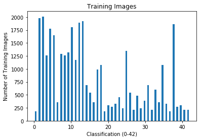

```
Training shape: (34799, 32, 32, 3)
(34799,)
After Fake Data Additions
```

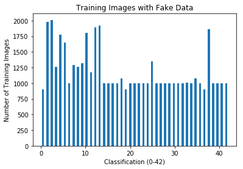

```
Training shape after added data: (51419, 32, 32, 1)
(51419, 43)
Valid Shape: (4410, 32, 32, 1)
(4410, 43)
Test Shape: (12630, 32, 32, 1)
(12630, 43)
```

```python
# Preprocessing
print("Prior to Fake Data Additions")
plt.hist(y_train, n_classes, rwidth=.5)
plt.xlabel("Classification (0-42)")
plt.ylabel("Number of Training Images")
plt.title("Training Images")
plt.savefig('examples/data_hist.png')
plt.show()
print("Training shape: " + str(X_train.shape))
print(y_train.shape)


avg = np.mean(X_train)
stdev = np.std(X_train)
angles = [-9,-4,4,9]
filters = generate_rot_filters(angles, image_shape)
train_data, train_labels = preprocess(X_train,y_train, avg, stdev,n_classes,filters, add_data=True)

print("After Fake Data Additions")
with_fake_data = np.zeros([train_labels.shape[0]])
for i,labl in enumerate(train_labels):
    with_fake_data[i] = max_index(labl)
plt.hist(with_fake_data, n_classes, rwidth=.5)
plt.xlabel("Classification (0-42)")
plt.ylabel("Number of Training Images")
plt.title("Training Images with Fake Data")
plt.savefig('examples/fake_data_hist.png')
plt.show()

valid_data, valid_labels = preprocess(X_valid,y_valid, avg, stdev,n_classes,filters, add_data=False)
test_data, test_labels = preprocess(X_test, y_test, avg, stdev,n_classes,filters,add_data=False)

print("Training shape after added data: " + str(train_data.shape))
print(train_labels.shape)
print("Valid Shape: " + str(valid_data.shape))
print(valid_labels.shape)
print("Test Shape: " + str(test_data.shape))
print(test_labels.shape)
```

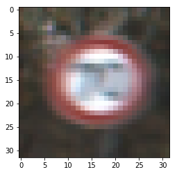

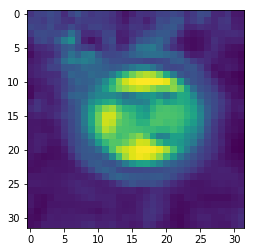

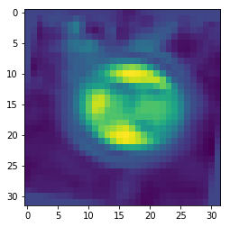

```python
plt.imshow(X_train[0])
plt.savefig('examples/before.png')
plt.show()

plt.imshow(np.reshape(train_data[0],[32,32]))
plt.savefig('examples/after.png')
plt.show()

plt.imshow(rotate(np.reshape(train_data[0],[32,32]), -9, filters[0]))
plt.savefig('examples/rotated.png')
plt.show()
```

### Model Architecture

```python
import tensorflow as tf
import math
```

```python
mu = 0
sigma = 0.1

image_depth = 1

weight_shapes = [
    (5, 5, image_depth, 84),
    (5, 5, 84, 32),
    (5*5*32, 120),
    (120,84),
    (84,n_classes)
]

def param_count(weight_shapes):
    total = 0
    for shape in weight_shapes:
        params = 1
        for dim in shape:
            params *= dim
        total += params + shape[-1]
    return total

print("Parameter Count: " + str(param_count(weight_shapes)))

weights = [ tf.Variable(tf.truncated_normal(shape=x,mean=mu,stddev=sigma), name="weight1_"+str(i)) for i,x in enumerate(weight_shapes)]
biases = [tf.Variable(tf.zeros([x[-1]]), name="bias1_"+str(i)) for i,x in enumerate(weight_shapes)]
```

```
Parameter Count: 179355
```

```python
def conv2d(images, weight, bias, stride=1, padding="VALID"):
    layer = tf.nn.bias_add(tf.nn.conv2d(images,weight,strides=[1,stride,stride,1],padding=padding), bias)
    return tf.nn.relu(layer)

def pool(images, k=2):
    return tf.nn.max_pool(images,ksize=[1,k,k,1],strides=[1,k,k,1],padding="VALID")

def fc_net(data, weights, biases, dropout_prob):
    logits = data
    for i in range(len(weights)):
        logits = tf.matmul(logits, weights[i]) + biases[i]
        if i < len(weights)-1:
            logits = tf.nn.relu(logits)
    return logits

def conv_net(images, weights, biases, dropout):
    logits = conv2d(images,weights[0],biases[0])
    logits = pool(logits)
    logits = conv2d(logits,weights[1],biases[1])
    logits = pool(logits)

    logits = tf.reshape(logits, [-1,weights[2].get_shape().as_list()[0]])
    logits = tf.nn.dropout(logits, dropout)

    logits = fc_net(logits, weights[2:], biases[2:], dropout)
    return logits
```

```python
data_inputs = tf.placeholder(tf.float32, [None, X_train.shape[1], X_train.shape[2],image_depth], name="input_placeholder")
data_labels = tf.placeholder(tf.float32, [None, n_classes], name="label_placeholder")

dropout = tf.placeholder(tf.float32, name="dropout_placeholder")
learning_rate = tf.placeholder(tf.float32, name="learning_rate_placeholder")
momentum = tf.placeholder(tf.float32, name="momentum_placeholder")

logits1 = conv2d(data_inputs,weights[0],biases[0])
logits = pool(logits1)
logits2 = conv2d(logits,weights[1],biases[1])
logits = pool(logits2)

logits = tf.reshape(logits, [-1,weights[2].get_shape().as_list()[0]])
logits = tf.nn.dropout(logits, dropout)

logits = fc_net(logits, weights[2:], biases[2:], dropout)

cost = tf.reduce_mean(tf.nn.softmax_cross_entropy_with_logits(logits=logits,labels=data_labels))
optimizer = tf.train.MomentumOptimizer(learning_rate=learning_rate, momentum=momentum).minimize(cost)

equal_list = tf.equal(tf.argmax(logits,1), tf.argmax(data_labels,1))
accuracy = tf.reduce_mean(tf.cast(equal_list, tf.float32))

save_file = './net_model.ckpt'
saver = tf.train.Saver()

init = tf.global_variables_initializer()
```

### Train, Validate and Test the Model

A validation set can be used to assess how well the model is performing. A low accuracy on the training and validation sets imply underfitting. A high accuracy on the training set but low accuracy on the validation set implies overfitting.

```python
def stop_early(loss,threshold):
    if len(loss) > 5:
        diffs = [loss[-i-1]-loss[-i] for i in range(5,0,-1)]
        if sum(diffs)/len(diffs) < threshold:
            return True
    return False

## Used to track hyperparameter experimentation
def write_to_file(file_name, weight_shapes, loss, rate, moment, epochs, batch_size, dropout_prob, acc):
    with open(file_name, 'a') as file:
        file.write("\nWeight shapes: \n")
        for weight in weight_shapes:
            file.write(str(weight) + str('\n'))
        file.write('Learning Rate: ' + str(rate) + '\n')
        file.write('Momentum: ' + str(moment) + '\n')
        file.write('Epoch Count: ' + str(epochs) + '\n')
        file.write('Batch size: ' + str(batch_size) + '\n')
        file.write("Dropout Probability: " + str(dropout_prob) + '\n')
        file.write('Loss: ' + str(loss) + '\n')
        file.write('Final Accuracy: ' + str(acc) + '\n\n')
```

```
Session Start
Epoch: 1
Training Cost: 861.525827646
Cost: 0.574483, Accuracy: 0.808
Epoch: 2
Training Cost: 277.526575744
Cost: 0.416865, Accuracy: 0.872
Epoch: 3
Training Cost: 185.29495053
Cost: 0.323686, Accuracy: 0.908
Epoch: 4
Training Cost: 144.414652124
Cost: 0.161357, Accuracy: 0.952
Epoch: 5
Training Cost: 119.361833483
Cost: 0.193143, Accuracy: 0.972
Epoch: 6
Training Cost: 99.858748138
Cost: 0.348587, Accuracy: 0.94
Epoch: 7
Training Cost: 91.3634804711
Cost: 0.144639, Accuracy: 0.956
Epoch: 8
Training Cost: 80.8049431853
Cost: 0.10046, Accuracy: 0.976
Epoch: 9
Training Cost: 42.8165179547
Cost: 0.142559, Accuracy: 0.96
Epoch: 10
Training Cost: 36.3483669274
Cost: 0.0540522, Accuracy: 0.98
Epoch: 11
Training Cost: 33.1100447597
Cost: 0.0933644, Accuracy: 0.968
Epoch: 12
Training Cost: 31.7341330945
Cost: 0.0465075, Accuracy: 0.972
Epoch: 13
Training Cost: 29.5950093707
Cost: 0.0843992, Accuracy: 0.98
```

[output cut: 49 more lines]

```
Training Cost: 22.0277081099
Cost: 0.105664, Accuracy: 0.976
Epoch: 31
Training Cost: 23.9948475123
Cost: 0.127648, Accuracy: 0.964
Epoch: 32
Training Cost: 22.4297803445
Cost: 0.105973, Accuracy: 0.968
Epoch: 33
Training Cost: 21.6464282637
Cost: 0.0721924, Accuracy: 0.984
Epoch: 34
Training Cost: 22.4092288231
Cost: 0.110992, Accuracy: 0.964
Validation Accuracy: 0.973696
```

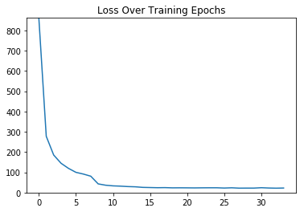

```python
### Model Training

rate = .05
moment = .75
epochs = 40
batch_size = 128
dropout_prob = .5

with tf.Session() as sess:
    print("Session Start")
    sess.run(init)
    n_batches = math.ceil(train_data.shape[0]/batch_size)
    loss = []
    epoch_count = 0
    stop_early_count = 0
    for epoch in range(epochs):
        epoch_count += 1
        if epoch >13: rate = .001
        elif epoch > 7: rate = .01
        if stop_early(loss, .1):
            if stop_early_count > 4:
                break
            moment = moment*.75
            stop_early_count += 1
        train_data, train_labels = shuffle(train_data, train_labels)
        running_cost = 0
        for batch in range(1,n_batches):
            batch_x = train_data[batch*batch_size-batch_size:batch*batch_size]
            batch_y = train_labels[batch*batch_size-batch_size:batch*batch_size]
            feed = {learning_rate: rate, momentum: moment,\
                                           dropout: dropout_prob, data_inputs: batch_x, data_labels: batch_y}
            optcost = sess.run([optimizer,cost], feed_dict=feed)
            running_cost += optcost[1]
        loss.append(running_cost)
        print("Epoch: " + str(epoch+1))
        print("Training Cost: " + str(running_cost))
        valid_data, valid_labels = shuffle(valid_data, valid_labels)
        validation = {dropout: 1., data_inputs: valid_data[:250], data_labels: valid_labels[:250]}
        accost = sess.run([accuracy,cost], feed_dict=validation)
        print("Cost: " + str(accost[1]) + ", Accuracy: " + str(accost[0]))

    acc = sess.run(accuracy, feed_dict={dropout: 1., data_inputs: valid_data, data_labels: valid_labels})
    print("Validation Accuracy: " + str(acc))
    saver.save(sess,save_file)

    write_to_file('past_runs.txt', weight_shapes, loss, rate, moment, epoch_count, batch_size, dropout_prob, acc)

    plt.plot(np.arange(len(loss)), loss)
    plt.ylim([0,loss[0]])
    plt.title("Loss Over Training Epochs")
    plt.show()
```

```python
with tf.Session() as sess:
    print("Session Start\n")
    saver.restore(sess, save_file)
    train_acc = 0
    for i in range((train_data.shape[0]//10000)-1):
        train_acc += sess.run(accuracy,feed_dict={dropout:1., data_inputs:train_data[i:i+10000],\
                                                     data_labels:train_labels[i:i+10000]})
    print("Training Set")
    print("Accuracy: " + str(train_acc/(train_data.shape[0]//10000-1)) + "\n")
    datas = [valid_data,test_data]
    labls = [valid_labels,test_labels]
    titles = ["Validation", "Test"]
    for d,l,t in zip(datas,labls,titles):
        accost = sess.run([cost,accuracy], feed_dict={dropout: 1.0, data_inputs: d, data_labels: l})
        print(t + " Set")
        print("Cost: " + str(accost[0]))
        print("Accuracy: " + str(accost[1]) + "\n")
```

```
Session Start

Training Set
Accuracy: 0.998600006104

Validation Set
Cost: 0.0860005
Accuracy: 0.973696

Test Set
Cost: 0.188739
Accuracy: 0.957799
```

## Step 3: Test a Model on New Images

To give yourself more insight into how your model is working, download at least five pictures of German traffic signs from the web and use your model to predict the traffic sign type.

You may find `signnames.csv` useful as it contains mappings from the class id (integer) to the actual sign name.

### Load and Output the Images

[figure not shown]

```
Label: 38
```

[figure not shown]

```
Label: 27
```

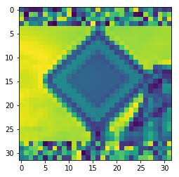

```
Label: 12
```

[figure not shown]

```
Label: 11
```

[figure not shown]

```
Label: 2
```

[figure not shown]

```
Label: 3
```

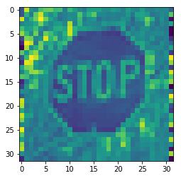

```
Label: 14
```

```python
from PIL import Image
import PIL
import os

path = './internet_images/'
pic_files = []
pic_labels = []
for dirName, subDirList, fileList in os.walk(path):
    for fileName in fileList:
        if '.jpg' in fileName.lower():
            pic_files.append(os.path.join(dirName,fileName))
            period = fileName.find('.')
            pic_labels.append(fileName[period-2:period])
            if fileName[period-2] == '_': pic_labels[-1] = fileName[period-1]


traffic_signs = np.zeros([len(pic_files), train_data.shape[1], train_data.shape[2]], dtype=np.float32)

for i,file in enumerate(pic_files):
    pic = Image.open(file).convert('LA')
    maxsize = (32, 32)
    pic.thumbnail(maxsize, PIL.Image.ANTIALIAS)
    padded_pic = Image.fromarray(np.random.random(maxsize)*255)
    padded_pic.paste(pic, ((maxsize[0]-pic.size[0])//2,(maxsize[1]-pic.size[1])//2))
    pixels = np.array(padded_pic)
    traffic_signs[i,:,:] = pixels

for i,sign in enumerate(traffic_signs):
    plt.imshow(sign)
    plt.show()
    print("Label: " + pic_labels[i])

sign_data, sign_labels = preprocess_jpg(traffic_signs,np.array(pic_labels), avg, stdev, n_classes)
sign_data = traffic_signs.reshape((traffic_signs.shape[0],traffic_signs.shape[1],traffic_signs.shape[2],1))
```

### Predict the Sign Type for Each Image

```python
def top_5(logits):
    top5 = [(logits[i],i) for i in range(5)]
    top5 = sorted(top5,reverse=True)
    for i in range(5,len(logits)):
        for j,el in enumerate(top5):
            if logits[i] > el[0]:
                temp = (logits[i],i)
                for k in range(j,len(top5)):
                    top5[k],temp = temp,top5[k]
                break
    return top5

def softmax(logits):
    logits = logits/100
    normalizer = sum([math.exp(logit) for logit in logits])
    for i,logit in enumerate(logits):
        logits[i] = math.exp(logit)/normalizer
    return logits

def max_index(log):
    max_i = 0
    for i in range(log.shape[0]):
        if log[i] > log[max_i]:
            max_i = i
    return max_i
```

```
For image:
```

[figure not shown]

```
Real Label: Keep right
Predicted Label: Keep right

Top 5 Predictions:
Label: Keep right–> Prediction Confidence: 0.999881
Label: Yield–> Prediction Confidence: 0.000119031
Label: Right of Way–> Prediction Confidence: 1.38229e-07
Label: Road work–> Prediction Confidence: 4.5846e-08
Label: Priority road–> Prediction Confidence: 5.63471e-09
(Predicted image displayed below)
```

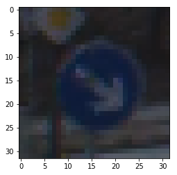

```
For image:
```

[figure not shown]

```
Real Label: Pedestrians
Predicted Label: General caution

Top 5 Predictions:
Label: General caution–> Prediction Confidence: 0.997157
Label: Pedestrians–> Prediction Confidence: 0.00157825
Label: Wild animals crossing–> Prediction Confidence: 0.00033264
Label: Road narrows on the right–> Prediction Confidence: 0.000276632
Label: Go straight or left–> Prediction Confidence: 0.000252305
(Predicted image displayed below)
```

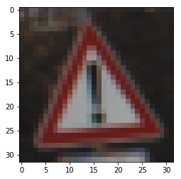

```
For image:
```

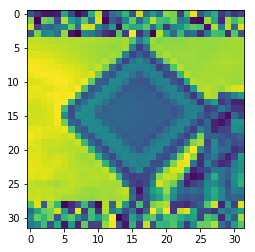

```
Real Label: Priority road
Predicted Label: Priority road

Top 5 Predictions:
Label: Priority road–> Prediction Confidence: 0.999943
Label: No passing–> Prediction Confidence: 3.44303e-05
Label: Yield–> Prediction Confidence: 1.11475e-05
Label: No entry–> Prediction Confidence: 5.83228e-06
Label: Roundabout mandatory–> Prediction Confidence: 2.70981e-06
(Predicted image displayed below)
```

[figure not shown]

```
For image:
```

[figure not shown]

```
Real Label: Right of Way
Predicted Label: Right of Way

Top 5 Predictions:
Label: Right of Way–> Prediction Confidence: 0.999077
Label: Beware of ice/snow–> Prediction Confidence: 0.000458759
Label: Pedestrians–> Prediction Confidence: 0.000433949
Label: Children crossing–> Prediction Confidence: 2.96425e-05
Label: Double curve–> Prediction Confidence: 2.69535e-07
(Predicted image displayed below)
```

[figure not shown]

```
For image:
```

[figure not shown]

```
Real Label: Speed limit (50km/h)
Predicted Label: Speed limit (50km/h)

Top 5 Predictions:
Label: Speed limit (50km/h)–> Prediction Confidence: 0.666202
Label: Speed limit (30km/h)–> Prediction Confidence: 0.315747
Label: Speed limit (70km/h)–> Prediction Confidence: 0.00427005
Label: Speed limit (100km/h)–> Prediction Confidence: 0.00349992
Label: Speed limit (80km/h)–> Prediction Confidence: 0.00300471
(Predicted image displayed below)
```

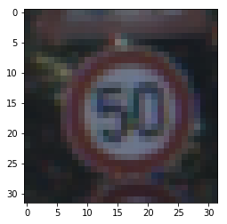

```
For image:
```

[figure not shown]

```
Real Label: Speed limit (60km/h)
Predicted Label: Roundabout mandatory

Top 5 Predictions:
Label: Roundabout mandatory–> Prediction Confidence: 0.626408
Label: Priority road–> Prediction Confidence: 0.169607
Label: End of no passing–> Prediction Confidence: 0.139186
Label: Keep right–> Prediction Confidence: 0.0221789
Label: No entry–> Prediction Confidence: 0.00824869
(Predicted image displayed below)
```

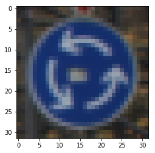

```
For image:
```

[2 more figures not shown]

```python
correct_predictions = []
for i in range(len(sign_data)):
    print("For image: ")
    plt.imshow(traffic_signs[i])
    plt.show()
    with tf.Session() as sess:
        saver.restore(sess,save_file)
        logs = sess.run([logits,accuracy], feed_dict=
                        {learning_rate: rate, momentum: moment,dropout:1.0,data_inputs: sign_data[i:i+1], data_labels: sign_labels[i:i+1]})
        logs[0] = np.reshape(logs[0], [-1])
        logs[0] = softmax(logs[0])
        print("Real Label: " + str(signnames[max_index(sign_labels[i])]))
        prediction = max_index(logs[0])
        print("Predicted Label: " + str(signnames[prediction]) + "\n")
        print("Top 5 Predictions: \n" + "\n".join(["Label: " + str(signnames[elm[1]]) + "–> Prediction Confidence: " + str(elm[0]) for elm in top_5(logs[0])]))
        print("(Predicted image displayed below)")
        plt.imshow(sign_types[prediction])
        plt.show()
        correct_predictions.append(logs[1])
        print("\n\n")
```

### Analyze Performance

```python
print("Performance Accuracy: " + str(sum(correct_predictions)/len(correct_predictions)))
```

```
Performance Accuracy: 0.714285714286
```

## Step 4: Visualize the Neural Network's State with Test Images

This Section is not required to complete but acts as an additional excersise for understaning the output of a neural network's weights. While neural networks can be a great learning device they are often referred to as a black box. We can understand what the weights of a neural network look like better by plotting their feature maps. After successfully training your neural network you can see what it's feature maps look like by plotting the output of the network's weight layers in response to a test stimuli image. From these plotted feature maps, it's possible to see what characteristics of an image the network finds interesting. For a sign, maybe the inner network feature maps react with high activation to the sign's boundary outline or to the contrast in the sign's painted symbol.

Provided for you below is the function code that allows you to get the visualization output of any tensorflow weight layer you want. The inputs to the function should be a stimuli image, one used during training or a new one you provided, and then the tensorflow variable name that represents the layer's state during the training process, for instance if you wanted to see what the LeNet lab's feature maps looked like for it's second convolutional layer you could enter conv2 as the tf_activation variable.

For an example of what feature map outputs look like, check out NVIDIA's results in their paper [End-to-End Deep Learning for Self-Driving Cars](https://devblogs.nvidia.com/parallelforall/deep-learning-self-driving-cars/) in the section Visualization of internal CNN State. NVIDIA was able to show that their network's inner weights had high activations to road boundary lines by comparing feature maps from an image with a clear path to one without. Try experimenting with a similar test to show that your trained network's weights are looking for interesting features, whether it's looking at differences in feature maps from images with or without a sign, or even what feature maps look like in a trained network vs a completely untrained one on the same sign image.

[figure not shown]

Your output should look something like this (above)

```python
def outputFeatureMap(image_input, tf_activation, saver, save_file, activation_min=-1, activation_max=-1 ,plt_num=1):
    with tf.Session() as sess:
        saver.restore(sess, save_file)
        activation = sess.run(tf_activation,feed_dict={dropout: 1.0, data_inputs : image_input})
    featuremaps = activation.shape[3]
    n_cols = 6
    n_rows = int(featuremaps/n_cols)+1
    plt.figure(plt_num, figsize=(activation.shape[1],activation.shape[2]))
    for featuremap in range(featuremaps):
        plt.subplot(n_rows, n_cols, featuremap+1)
        plt.title('FeatureMap ' + str(featuremap))
        if activation_min != -1 & activation_max != -1:
            plt.imshow(activation[0,:,:, featuremap], interpolation="nearest", vmin =activation_min, vmax=activation_max, cmap="gray")
        elif activation_max != -1:
            plt.imshow(activation[0,:,:, featuremap], interpolation="nearest", vmax=activation_max, cmap="gray")
        elif activation_min !=-1:
            plt.imshow(activation[0,:,:, featuremap], interpolation="nearest", vmin=activation_min, cmap="gray")
        else:
            plt.imshow(activation[0,:,:, featuremap], interpolation="nearest", cmap="gray")
    plt.show()
```